# Less Volume, More Creativity

Randy Pruim  
eCOTS 2014

## Focusing on R Essentials

### Less Volume, More Creativity

[figure not shown]

A lot of times you end up putting in a lot more volume, because you are teaching fundamentals and you are teaching concepts that you need to put in, but you may not necessarily use because they are building blocks for other concepts and variations that will come off of that … In the offseason you have a chance to take a step back and tailor it more specifically towards your team and towards your players.“  
Mike McCarthy, Head Coach, Green Bay Packers

### SIBKIS: See It Big, Keep It Simple

Perfection is achieved, not when there is nothing more to add, but when there is nothing left to take away.  
— Antoine de Saint-Exupery (writer, poet, pioneering aviator)

### Less Volume, More Creativity

One key to successfully introducing R is finding a set of commands that is

- **small**: fewer is better
- **coherent**: commands should be as similar as possible
- **powerful**: can do what needs doing

It is not enough to use R, it must be used elegantly.

The **mosaic** package offers one way to do this.

- [Minimal R Vignette](https://github.com/rpruim/mosaic/raw/master/inst/doc/MinimalR-vignette.pdf#page=2)

### A few little details

### R is case sensitive

- many students are *not* case sensitive

### Arrows and Tab

- up/down arrows scroll through history
- TAB completion can simplify typing

### If all else fails, try ESC

- If you see a + prompt, it means R is waiting for more input
- If this is unintentional, you probably have a typo
- ESC will get you pack to the command prompt

### The Most Important R Template

## **goal ( yyy ~ xxx , data = mydata )**

### The Most Important R Template

## **goal ( y ~ x , data = mydata )**

### The Most Important R Template

## **goal ( y ~ x , data = mydata , …)**

### Simpler version:

- `goal( ~ x, data = mydata )`

### Fancier version:

- `goal( y ~ x | z , data = mydata )`

### Unified version:

- `goal( formula , data = mydata )`

### 2 Questions

## **goal ( y ~ x , data = mydata )**

### What do you want R to do? (goal)

### What must R know to do that?

### 2 Questions

## **goal ( y ~ x , data = mydata )**

### What do you want R to do? (goal)

- This determines the function to use

### What must R know to do that?

- This determines the inputs to the function
- Must identify the variables and data frame

### What is the Goal?

- a scatter plot

### What does R need to know?

- which variable goes where
- which data set

## **goal ( y ~ x , data = mydata )**

## **xyplot ( births ~ dayofyear , data = Births78 )**

### Your turn: How do you make this plot?

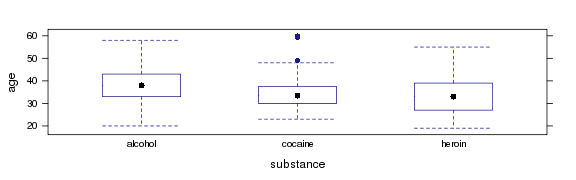

### Two Questions?

### Your turn: How do you make this plot?

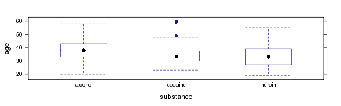

The data: `HELPrct`

Variables: `age`, `substance`

Command: `bwplot()`

**Raise your hand when you have created this plot**

### Your turn: How do you make this plot?

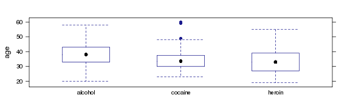

```r
bwplot( age ~ substance, data=HELPrct)
```

### Your turn: How about this one?

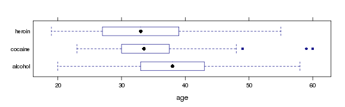

**Raise your hand when you have created this plot.**

### Your turn: How about this one?

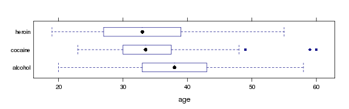

```r
bwplot( substance ~ age, data=HELPrct )
```

### Graphical Summaries: One Variable

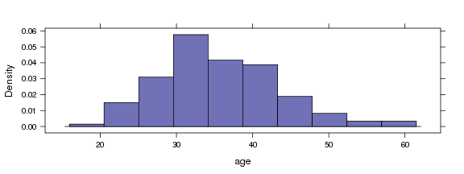

```r
histogram( ~ age, data=HELPrct)
```

Note: When there is **one variable** it is on the **right side** of the formula.

### Graphical Summaries: Overview

### One Variable

```r
  histogram( ~age, data=HELPrct )
densityplot( ~age, data=HELPrct )
     bwplot( ~age, data=HELPrct )
     qqmath( ~age, data=HELPrct )
freqpolygon( ~age, data=HELPrct )
   bargraph( ~sex, data=HELPrct )
```

### Two Variables

```r
xyplot(  i1 ~ age,       data=HELPrct )
bwplot( age ~ substance, data=HELPrct )
bwplot( substance ~ age, data=HELPrct )
```

- **i1** average number of drinks (standard units) consumed per day, in the past 30 days (measured at baseline)

### The Graphics Template

### **plotname ( y ~ x , data = mydata , …)**

### **plotname ( ~ x , data = mydata , …)**

### One variable

- `histogram()`, `qqmath()`, `densityplot()`, `freqpolygon()`, `bargraph()`

### Two Variables

- `xyplot()`, `bwplot()`

### Your turn

Create a plot of your own choosing with one of these data sets

```r
names(KidsFeet)    # 4th graders' feet
?KidsFeet
```

```r
names(Utilities)   # utility bill data
?Utilities
```

```r
names(NHANES)      # body shape, etc.
?NHANES
```

**Raise your hand when you have made a plot or two.**

*Type a question if you have trouble.*

### groups and panels

- Add `groups =`group to overlay.
- Use `y ~ x | z` to create multipanel plots.

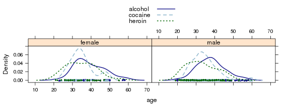

```r
densityplot( ~ age | sex, data=HELPrct,
               groups=substance,
               auto.key=TRUE)
```

### Bells & Whistles

- titles
- axis labels
- colors
- sizes
- transparency
- etc, etc.

My approach:

- Let the students ask or
- Let the data analysis drive

### Numerical Summaries: One Variable

Big idea:

- replace plot name with summary name
- nothing else changes

```
[1] 35.65
```

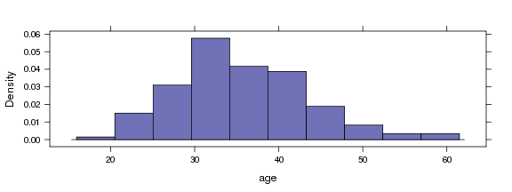

```r
histogram( ~ age, data=HELPrct )
     mean( ~ age, data=HELPrct )
```

### Other Summaries

The mosaic package includes formula aware versions of `mean()`, `sd()`, `var()`, `min()`, `max()`, `sum()`, `IQR()`, …

Also provides `favstats()` to compute our favorites.

```r
favstats( ~ age, data=HELPrct )
```

```
 min Q1 median Q3 max  mean   sd   n missing
  19 30     35 40  60 35.65 7.71 453       0
```

### Tallying

```r
tally( ~ sex, data=HELPrct)
```

```
female   male
   107    346
```

```r
tally( ~ substance, data=HELPrct)
```

```
alcohol cocaine  heroin
    177     152     124
```

### Numerical Summaries: Two Variables

Three ways to think about this. All do the same thing.

```r
sd(   age ~ substance, data=HELPrct )
sd( ~ age | substance, data=HELPrct )
sd( ~ age, groups=substance, data=HELPrct )
```

```
alcohol cocaine  heroin
  7.652   6.693   7.986
```

### Numerical Summaries: Tables

```r
tally( sex ~ substance, data=HELPrct )
```

```
        substance
sex      alcohol cocaine heroin
  female  0.2034  0.2697 0.2419
  male    0.7966  0.7303 0.7581
```

```r
tally( ~ sex + substance, data=HELPrct )
```

```
        substance
sex      alcohol cocaine heroin
  female      36      41     30
  male       141     111     94
```

### Numerical Summaries

```r
mean( age ~ substance | sex, data=HELPrct,  )
```

```
  A.F   C.F   H.F   A.M   C.M   H.M     F     M
39.17 34.85 34.67 37.95 34.36 33.05 36.25 35.47
```

- I've abbreviated the names to make things fit on slide
- Also works for `median()`, `min()`, `max()`, `sd()`, `var()`, `favstats()`, etc.

### One Template to Rule a Lot

- single and multiple variable graphical summaries
- single and multiple variabble numerical summaries
- linear models

```r
  mean( age ~ sex, data=HELPrct )
bwplot( age ~ sex, data=HELPrct )
    lm( age ~ sex, data=HELPrct )
```

```
female   male
 36.25  35.47
```

```
(Intercept)     sexmale
    36.2523     -0.7841
```

- We will return to modeling shortly.

### Some other things

The `mosaic` package includes some other things, too

- Data sets (you've already seen some of them)
- xtras: `xchisq.test()`, `xpnorm()`, `xqqmath()`
- `mPlot()` – interactive plot design
- simplified `histogram()` controls (e.g., `width`)
- simplified ways to add onto lattice plots

### xpnorm()

```r
xpnorm( 700, mean=500, sd=100)
```

```
If X ~ N(500,100), then

    P(X <= 700) = P(Z <= 2) = 0.9772
    P(X >  700) = P(Z >  2) = 0.0228
```

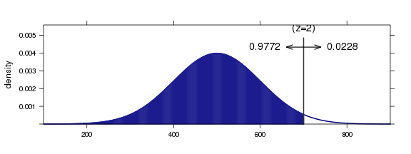

```
[1] 0.9772
```

### xpnorm()

```r
xpnorm( c(300, 700), mean=500, sd=100)
```

```
If X ~ N(500,100), then

    P(X <= 300) = P(Z <= -2) = 0.0228
    P(X <= 700) = P(Z <= 2) = 0.9772
    P(X >  300) = P(Z >  -2) = 0.9772
    P(X >  700) = P(Z >  2) = 0.0228
```

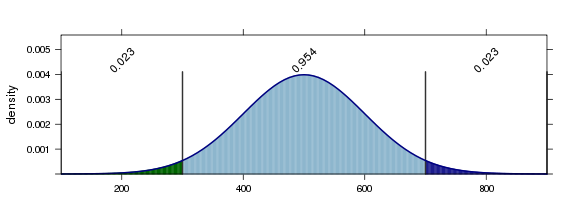

```
[1] 0.02275 0.97725
```

### xchisq.test()

```r
xchisq.test(phs)
```

```
    Pearson's Chi-squared test with Yates' continuity correction

data:  phs
X-squared = 24.43, df = 1, p-value = 7.71e-07

   104.00   10933.00
(  146.52) (10890.48)
[12.34]  [ 0.17]
<-3.51>  < 0.41>

   189.00   10845.00
(  146.48) (10887.52)
[12.34]  [ 0.17]
< 3.51>  <-0.41>

key:
    observed
    (expected)
    [contribution to X-squared]
    <residual>
```

### Next Up: Modeling

Modeling is really the starting point for the `mosaic` design.

- linear models (`lm()` and `glm()`) defined the template
- lattice graphics use the template (so we chose lattice)
- we added functionality so numerical summaries can be done with the same template
- additional things added to make modeling easier for beginners.